# Text Mining: Bag of Words

# What is text mining?

The process of distilling **actionable insights** from text.

The text mining workflow:

1. Define problem & specific goals
2. Identify text to be collected
3. Text orginization
4. Feature extraction
5. Analysis
6. Reach an insight, recommendation, or output

Semantic parsing: word order & sentence structure matters

With bag of words, each individual word/phrase is treated separately.

The `qdap` package is useful for counting words. Specifically, the function `freq_terms(text, top)` provides a fast, efficient way of doing so. Let’s take a look below.

```r
# Load qdap
library(qdap)
#if the qdap package is having trouble with the rJava package, you must direct the system environment to the Java program file
#Sys.setenv(JAVA_HOME='C:\\Program Files\\Java\\jre1.8.0_131')
#library(rJava)
# Create variable new text
new_text <- "DataCamp is the first online learning platform that focuses on building the best learning experience specifically for Data Science. We have offices in Boston and Belgium and to date, we trained over 250,000 (aspiring) data scientists in over 150 countries. These data science enthusiasts completed more than 9 million exercises. You can take free beginner courses, or subscribe for $25/month to get access to all premium courses."
# Print new_text to the console
print(new_text)
```

```
[1] "DataCamp is the first online learning platform that focuses on building the best learning experience specifically for Data Science. We have offices in Boston and Belgium and to date, we trained over 250,000 (aspiring) data scientists in over 150 countries. These data science enthusiasts complet…
```

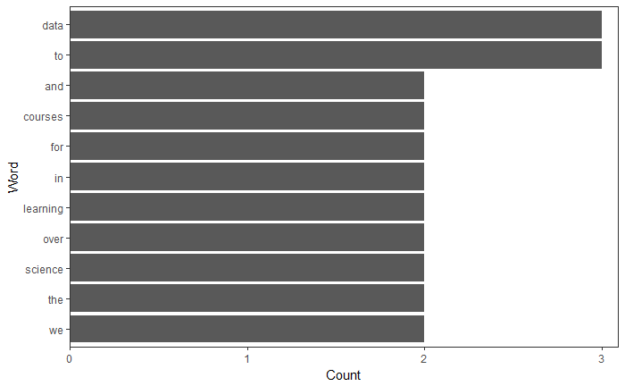

```r
# Find the 10 most frequent terms: term_count
term_count <- freq_terms(new_text, 10)
# Plot term_count
plot(term_count)
```

For the following work, we can use the example data set `Data` contained in the qdap package.

```r
#define data
df <- qdap::DATA
# View the structure of df
str(df)
```

```
'data.frame':   11 obs. of  5 variables:
 $ person: Factor w/ 5 levels "greg","researcher",..: 4 1 5 4 1 3 1 4 3 2 ...
 $ sex   : Factor w/ 2 levels "f","m": 2 2 2 2 2 1 2 2 1 1 ...
 $ adult : int  0 0 1 0 0 0 0 0 0 1 ...
 $ state : chr  "Computer is fun. Not too fun." "No it's not, it's dumb." "What should we do?" "You liar, it stinks!" ...
 $ code  : Factor w/ 11 levels "K1","K10","K11",..: 1 4 5 6 7 8 9 10 11 2 ...
```

```r
# Print out the number of rows in df
nrow(df)
```

```
[1] 11
```

```r
# Isolate text from df: dialogue_df
dialogue_df <- df$state
```

Use the `tm` package to create a word corpus. A corpus is a collection of documents.

There are two kinds of the corpus data type, the permanent corpus, PCorpus, and the volatile corpus, VCorpus. In essence, the difference between the two has to do with how the collection of documents is stored in your computer. In this course, we will use the volatile corpus, which is held in your computer’s RAM rather than saved to disk, just to be more memory efficient.

```r
# Load tm
library(tm)
# Make a vector source: dialogue_source
dialogue_source <- VectorSource(dialogue_df)
dialogue_source
```

```
$encoding
[1] ""

$length
[1] 11

$position
[1] 0

$reader
function (elem, language, id)
{
    if (!is.null(elem$uri))
        id <- basename(elem$uri)
    PlainTextDocument(elem$content, id = id, language = language)
}
<environment: namespace:tm>

$content
 [1] "Computer is fun. Not too fun."         "No it's not, it's dumb."               "What should we do?"
 [4] "You liar, it stinks!"                  "I am telling the truth!"               "How can we be certain?"
 [7] "There is no way."                      "I distrust you."                       "What are you talking about?"
[10] "Shall we move on?  Good then."         "I'm hungry.  Let's eat.  You already?"

attr(,"class")
[1] "VectorSource" "SimpleSource" "Source"
```

Now that we’ve converted our vector to a Source object, we pass it to another tm function, VCorpus(), to create our volatile corpus. Pretty straightforward, right?

The VCorpus object is a nested list, or list of lists. At each index of the VCorpus object, there is a PlainTextDocument object, which is essentially a list that contains the actual text data (content), as well as some corresponding metadata (meta). It can help to visualize a VCorpus object to conceptualize the whole thing.

```r
# Make a volatile corpus: dialogue_corpus
dialogue_corpus <- VCorpus(dialogue_source)
#Print out dialogue corpus
dialogue_corpus
```

```
<<VCorpus>>
Metadata:  corpus specific: 0, document level (indexed): 0
Content:  documents: 11
```

```r
#subset data corresponding to the 7th line
dialogue_corpus[[7]]
```

```
<<PlainTextDocument>>
Metadata:  7
Content:  chars: 16
```

```r
#subset the content correpsonding to the 7th line
dialogue_corpus[[7]][1]
```

```
$content
[1] "There is no way."
```

Use example data to make a corpus from both a vector and a dataframe:

```r
#use qdap example dataset
example_text <- data.frame(num = c(1,2,3),
                           Author1 = c("yes", "no", "maybe so"),
                           Author2 = c("Hello", "How are you?", "Am I doing this right?"), stringsAsFactors = FALSE)
# Print example_text to the console
str(example_text)
```

```
'data.frame':   3 obs. of  3 variables:
 $ num    : num  1 2 3
 $ Author1: chr  "yes" "no" "maybe so"
 $ Author2: chr  "Hello" "How are you?" "Am I doing this right?"
```

```r
# Create a DataframeSource on column 2 nd 3: df_source
df_source <- DataframeSource(example_text[ , 2:3])
# Convert df_source to a corpus: df_corpus
df_corpus <- VCorpus(df_source)
# Examine df_corpus
df_corpus
```

```
<<VCorpus>>
Metadata:  corpus specific: 0, document level (indexed): 0
Content:  documents: 3
```

```r
# Create a VectorSource on column 3: vec_source
vec_source <- VectorSource(example_text[,3])
# Convert vec_source to a corpus: vec_corpus
vec_corpus <- VCorpus(vec_source)
# Examine vec_corpus
vec_corpus
```

```
<<VCorpus>>
Metadata:  corpus specific: 0, document level (indexed): 0
Content:  documents: 3
```

# Cleaning & Preprocessing Data

## Useful preprocssing functions

There are a number of useful functions available in the `tm` package useful for cleaning up text.

tolower() - actually a base r function  
removePunctuation()  
removeNumbers()  
stripWhiteSpace()  
removeWords()

```r
# Create the object: text
text <- "<b>She</b> woke up at       6 A.M. It\'s so early!  She was only 10% awake and began drinking coffee in front of her computer."
# All lowercase
tolower(text)
```

```
[1] "<b>she</b> woke up at       6 a.m. it's so early!  she was only 10% awake and began drinking coffee in front of her computer."
```

```r
# Remove punctuation
removePunctuation(text)
```

```
[1] "bSheb woke up at       6 AM Its so early  She was only 10 awake and began drinking coffee in front of her computer"
```

```r
# Remove numbers
removeNumbers(text)
```

```
[1] "<b>She</b> woke up at        A.M. It's so early!  She was only % awake and began drinking coffee in front of her computer."
```

```r
# Remove whitespace
stripWhitespace(text)
```

```
[1] "<b>She</b> woke up at 6 A.M. It's so early! She was only 10% awake and began drinking coffee in front of her computer."
```

The qdap package offers other text cleaning functions. Each is useful in its own way and is particularly powerful when combined with the others.

bracketX(): Remove all text within brackets (e.g. “It’s (so) cool” becomes “It’s cool”)  
replace_number(): Replace numbers with their word equivalents (e.g. “2” becomes “two”)  
replace_abbreviation(): Replace abbreviations with their full text equivalents (e.g. “Sr” becomes “Senior”)  
replace_contraction(): Convert contractions back to their base words (e.g. “shouldn’t” becomes “should not”)  
replace_symbol() Replace common symbols with their word equivalents (e.g. “$” becomes “dollar”)

```r
#example text to clean
text
```

```
[1] "<b>She</b> woke up at       6 A.M. It's so early!  She was only 10% awake and began drinking coffee in front of her computer."
```

```r
# Remove text within brackets
bracketX(text)
```

```
[1] "She woke up at 6 A.M. It's so early! She was only 10% awake and began drinking coffee in front of her computer."
```

```r
# Replace numbers with words
replace_number(text)
```

```
[1] "<b>She</b> woke up at six A.M. It's so early! She was only ten% awake and began drinking coffee in front of her computer."
```

```r
# Replace abbreviations
replace_abbreviation(text)
```

```
[1] "<b>She</b> woke up at 6 AM It's so early! She was only 10% awake and began drinking coffee in front of her computer."
```

```r
# Replace contractions
replace_contraction(text)
```

```
[1] "<b>She</b> woke up at 6 A.M. it is so early! She was only 10% awake and began drinking coffee in front of her computer."
```

```r
# Replace symbols with words
replace_symbol(text)
```

```
[1] "<b>She</b> woke up at 6 A.M. It's so early! She was only 10 percent awake and began drinking coffee in front of her computer."
```

## Stop words

Stop words are frequent but often provide little information. The `tm` package contains 174 stop words in the common list.

When using stopwords, you can add your own stop words by making a combinedf vector as in the example below:

```r
# List standard English stop words
stopwords("en")
```

```
  [1] "i"          "me"         "my"         "myself"     "we"         "our"        "ours"       "ourselves"  "you"        "your"
 [11] "yours"      "yourself"   "yourselves" "he"         "him"        "his"        "himself"    "she"        "her"        "hers"
 [21] "herself"    "it"         "its"        "itself"     "they"       "them"       "their"      "theirs"     "themselves" "what"
 [31] "which"      "who"        "whom"       "this"       "that"       "these"      "those"      "am"         "is"         "are"
 [41] "was"        "were"       "be"         "been"       "being"      "have"       "has"        "had"        "having"     "do"
 [51] "does"       "did"        "doing"      "would"      "should"     "could"      "ought"      "i'm"        "you're"     "he's"
 [61] "she's"      "it's"       "we're"      "they're"    "i've"       "you've"     "we've"      "they've"    "i'd"        "you'd"
 [71] "he'd"       "she'd"      "we'd"       "they'd"     "i'll"       "you'll"     "he'll"      "she'll"     "we'll"      "they'll"
 [81] "isn't"      "aren't"     "wasn't"     "weren't"    "hasn't"     "haven't"    "hadn't"     "doesn't"    "don't"      "didn't"
 [91] "won't"      "wouldn't"   "shan't"     "shouldn't"  "can't"      "cannot"     "couldn't"   "mustn't"    "let's"      "that's"
[101] "who's"      "what's"     "here's"     "there's"    "when's"     "where's"    "why's"      "how's"      "a"          "an"
[111] "the"        "and"        "but"        "if"         "or"         "because"    "as"         "until"      "while"      "of"
[121] "at"         "by"         "for"        "with"       "about"      "against"    "between"    "into"       "through"    "during"
[131] "before"     "after"      "above"      "below"      "to"         "from"       "up"         "down"       "in"         "out"
[141] "on"         "off"        "over"       "under"      "again"      "further"    "then"       "once"       "here"       "there"
[151] "when"       "where"      "why"        "how"        "all"        "any"        "both"       "each"       "few"        "more"
[161] "most"       "other"      "some"       "such"       "no"         "nor"        "not"        "only"       "own"        "same"
[171] "so"         "than"       "too"        "very"
```

```r
# Print text without standard stop words
removeWords(text, stopwords("en"))
```

```
[1] "<b>She</b> woke         6 A.M. It's  early!  She   10% awake  began drinking coffee  front   computer."
```

```r
# Add "coffee" and "bean" to the list: new_stops
new_stops <- c("coffee", "bean", stopwords("en"))
# Remove stop words from text
removeWords(text, new_stops)
```

```
[1] "<b>She</b> woke         6 A.M. It's  early!  She   10% awake  began drinking   front   computer."
```

## Word Stemming

word stemming is another useful preprocessing step.

stem_word()  
stem_completion()  
complete_words()

```r
# Create complicate
complicate <- c("complicated", "complication", "complicatedly")
# Perform word stemming: stem_doc
stem_doc <- stemDocument(complicate)
stem_doc
```

```
[1] "complic" "complic" "complic"
```

```r
# Create the completion dictionary: comp_dict
comp_dict <- "complicate"
# Perform stem completion: complete_text
complete_text <- stemCompletion(stem_doc, comp_dict)
# Print complete_text
complete_text
```

```
     complic      complic      complic
"complicate" "complicate" "complicate"
```

Here’s another example in which we try to perform word stemming on similar words in the same sentence.

```r
# create text
text_data <- "In a complicated haste, Tom rushed to fix a new complication, too complicatedly."
#define completed dictionary
comp_dict <- c("In", "a", "complicate", "haste", "Tom", "rush", "to", "fix", "new", "too")
# Remove punctuation: rm_punc
rm_punc <- removePunctuation(text_data)
# Create character vector: n_char_vec
n_char_vec <- unlist(strsplit(rm_punc, split = ' '))
# Perform word stemming: stem_doc
stem_doc <- stemDocument(n_char_vec)
# Print stem_doc
stem_doc
```

```
 [1] "In"      "a"       "complic" "hast"    "Tom"     "rush"    "to"      "fix"     "a"       "new"     "complic" "too"     "complic"
```

```r
# Re-complete stemmed document: complete_doc
complete_doc <- stemCompletion(stem_doc, comp_dict)
# Print complete_doc
complete_doc
```

```
          In            a      complic         hast          Tom         rush           to          fix            a          new      complic
        "In"          "a" "complicate"      "haste"        "Tom"       "rush"         "to"        "fix"          "a"        "new" "complicate"
         too      complic
       "too" "complicate"
```

The `tm_map` function is a useful way to apply cleaning functions to a corpus.

Notice how the tm package functions do not need content_transformer(), but base R and qdap functions do.

Be careful when creating functions; the order of cleaning steps makes a difference.

```r
presidents <- data.frame(pres_debate_raw2012, stringsAsFactors = FALSE)
#examine presidents
str(presidents)
```

```
'data.frame':   94 obs. of  2 variables:
 $ person  : Factor w/ 3 levels "LEHRER","OBAMA",..: 1 3 1 3 2 1 2 1 2 3 ...
 $ dialogue: chr  "We'll talk about -- specifically about health care in a moment. But what -- do you support the voucher system, Governor?" "What I support is no change for current retirees and near-retirees to Medicare. And the president supports taking $716 billion "| __truncated__ "And what abou…
```

```r
#make presidents a source document
presidents_source <- DataframeSource(presidents)
#make presidents_source into a corpus
presidents_corpus <- VCorpus(presidents_source)
#exampine the presidents_corpus
presidents_corpus[[43]]
```

```
<<PlainTextDocument>>
Metadata:  7
Content:  chars: 1895
```

```r
#Build a function to clean the corpus
clean_corpus <- function(corpus){
  corpus <- tm_map(corpus, stripWhitespace)
  corpus <- tm_map(corpus, removePunctuation)
  corpus <- tm_map(corpus, content_transformer(tolower))
  corpus <- tm_map(corpus, removeWords, stopwords("en"))
  return(corpus)
}
# Apply your customized function to the presidents_corpus: clean_corp
clean_corp <- clean_corpus(presidents_corpus)
# Print out a cleaned up dialogue
clean_corp[[43]][1]
```

```
$content
[1] "2"
[2] "well four years ago    running  office   traveling around     conversations  governor romney talks    wasnt just  small businesses  seeing costs skyrocket   couldnt get affordable coverage even   wanted  provide    employees  wasnt just     biggest driver   federal deficit  overall health care …
```

```r
# Print out the same dialogue in original form
presidents[43, 2]
```

```
[1] "Well, four years ago, when I was running for office, I was traveling around and having those same conversations that Governor Romney talks about. And it wasn't just that small businesses were seeing costs skyrocket and they couldn't get affordable coverage even if they wanted to provide it to t…
```

## TDM vs. DTM

Document Term Matrix makes each term a column, and each document a row

```r
# Create the dtm from the corpus: pres_dtm
pres_dtm <- DocumentTermMatrix(clean_corp)
#print out pres_dtm data
pres_dtm
```

```
<<DocumentTermMatrix (documents: 94, terms: 1225)>>
Non-/sparse entries: 3049/112101
Sparsity           : 97%
Maximal term length: 16
Weighting          : term frequency (tf)
```

```r
#convert DTM to a matrix (pres_m)
pres_m <- as.matrix((pres_dtm))
dim(pres_m)
```

```
[1]   94 1225
```

```r
#review a portion of the matrix
pres_m[45:51, 123:130]
```

```
    Terms
Docs board boon borrow borrowing bowlessimpson briefly bring bringing
  45     0    0      0         0             0       0     0        1
  46     0    0      0         0             0       0     0        0
  47     2    0      0         0             0       0     0        1
  48     3    0      0         0             0       0     0        0
  49     0    0      0         0             0       0     0        0
  50     0    0      0         0             0       0     0        0
  51     0    0      0         0             0       0     0        0
```

Where as, a Term Document Matrix makes each row a term, and each column a document.

```r
# Create the TDM from the corpus: pres_tdm
pres_tdm <- TermDocumentMatrix(clean_corp)
#print out pres_tdm data
pres_tdm
```

```
<<TermDocumentMatrix (terms: 1225, documents: 94)>>
Non-/sparse entries: 3049/112101
Sparsity           : 97%
Maximal term length: 16
Weighting          : term frequency (tf)
```

```r
#convert TDM to a matrix (pres_m)
pres_m <- as.matrix((pres_tdm))
dim(pres_m)
```

```
[1] 1225   94
```

```r
#review a portion of the matrix
pres_m[123:130, 45:51]
```

```
               Docs
Terms           45 46 47 48 49 50 51
  board          0  0  2  3  0  0  0
  boon           0  0  0  0  0  0  0
  borrow         0  0  0  0  0  0  0
  borrowing      0  0  0  0  0  0  0
  bowlessimpson  0  0  0  0  0  0  0
  briefly        0  0  0  0  0  0  0
  bring          0  0  0  0  0  0  0
  bringing       1  0  1  0  0  0  0
```

# Text Mining Visuals

```r
# Calculate the rowSums: term_frequency
term_frequency <- rowSums(pres_m)
# Sort term_frequency in descending order
term_frequency <- sort(term_frequency, decreasing = TRUE)
# View the top 10 most common words
head(term_frequency, 10)
```

```
    people      going   governor      thats        can government       care  insurance        get       make
        57         50         40         40         36         36         34         32         31         31
```

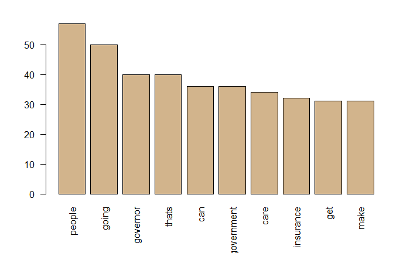

```r
# Plot a barchart of the 10 most common words
barplot(term_frequency[1:10], col = "tan", las = 2)
```

If you are OK giving up some control over the exact preprocessing steps, then a fast way to get frequent terms is with freq_terms() from qdap.

Making a basic plot of the results is easy. Just call plot() on the freq_terms() object.

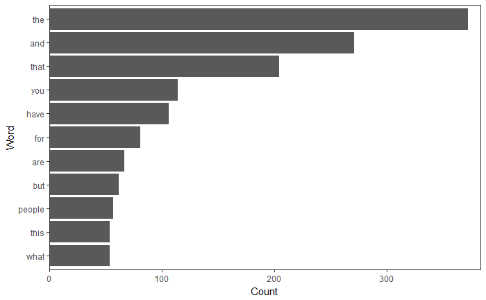

```r
# Create frequency
frequency <- freq_terms(presidents$dialogue, top = 10, at.least = 3, stopwords = "Top200Words")
# Make a frequency barchart
plot(frequency)
```

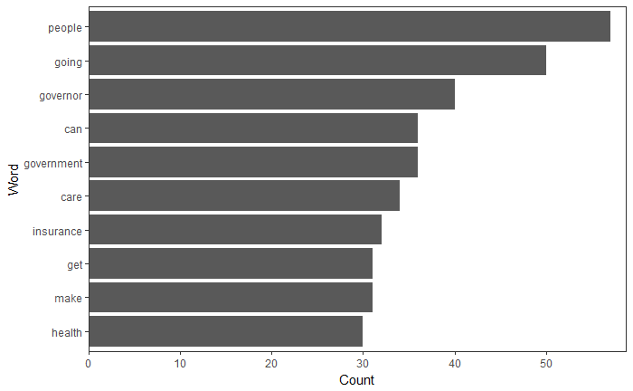

```r
# Create frequency2
frequency2 <- freq_terms(presidents$dialogue, top = 10, at.least = 3, stopwords = tm::stopwords("english"))
# Make a frequency2 barchart
plot(frequency2)
```